# CA2 Data Visualization

We can see how gender influences when you purchase items:

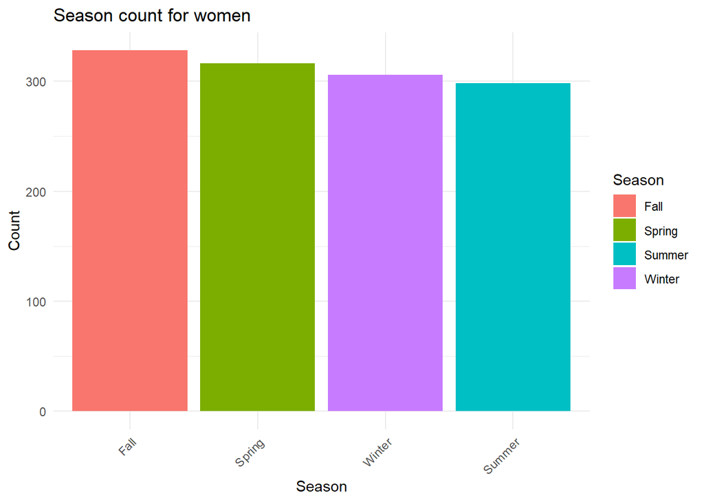

```r
season_women<-sqldf("select Season, count(Season) as count from df1 where Gender == 'Female' group by Season order by count desc")
#View(season_women)

ggplot(season_women, aes(x = reorder(Season, -count), y = count, fill = Season)) +
  geom_bar(stat = "identity") +
  labs(title = "Season count for women", x = "Season", y = "Count") +
  theme_minimal() +
  theme(axis.text.x = element_text(angle = 45, hjust = 1))
```

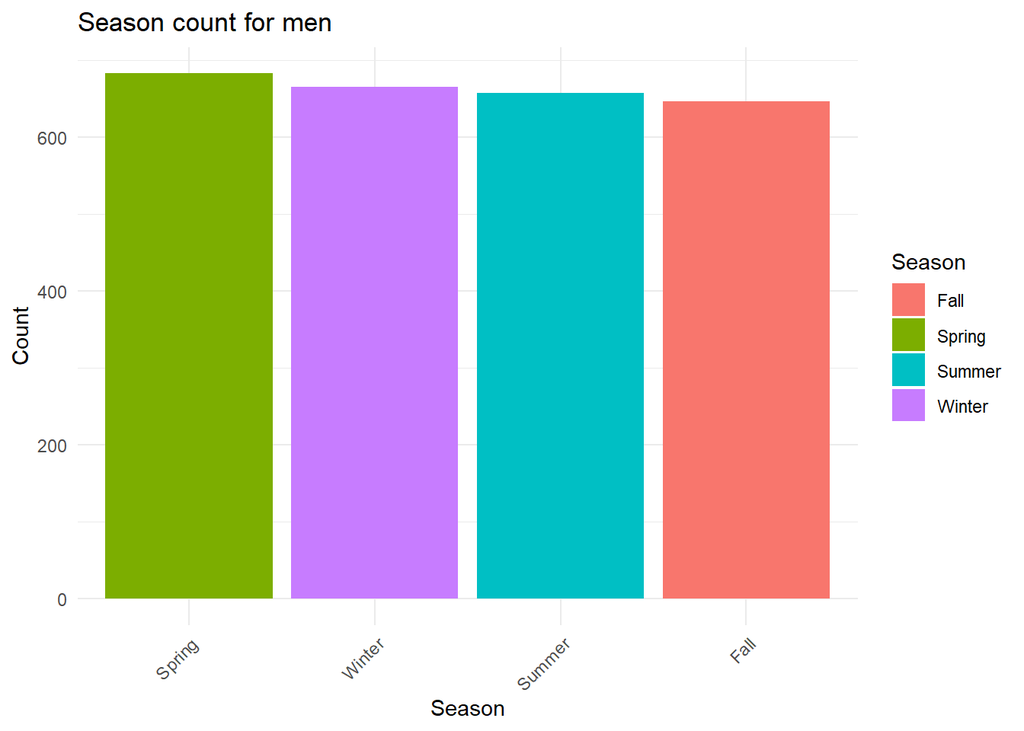

```r
season_men<-sqldf("select Season, count(Season) as count from df1 where Gender == 'Male' group by Season order by count desc")
#View(season_men)

ggplot(season_men, aes(x = reorder(Season, -count), y = count, fill = Season)) +
  geom_bar(stat = "identity") +
  labs(title = "Season count for men", x = "Season", y = "Count") +
  theme_minimal() +
  theme(axis.text.x = element_text(angle = 45, hjust = 1))
```

We can also look at how age influences when you make purchases:

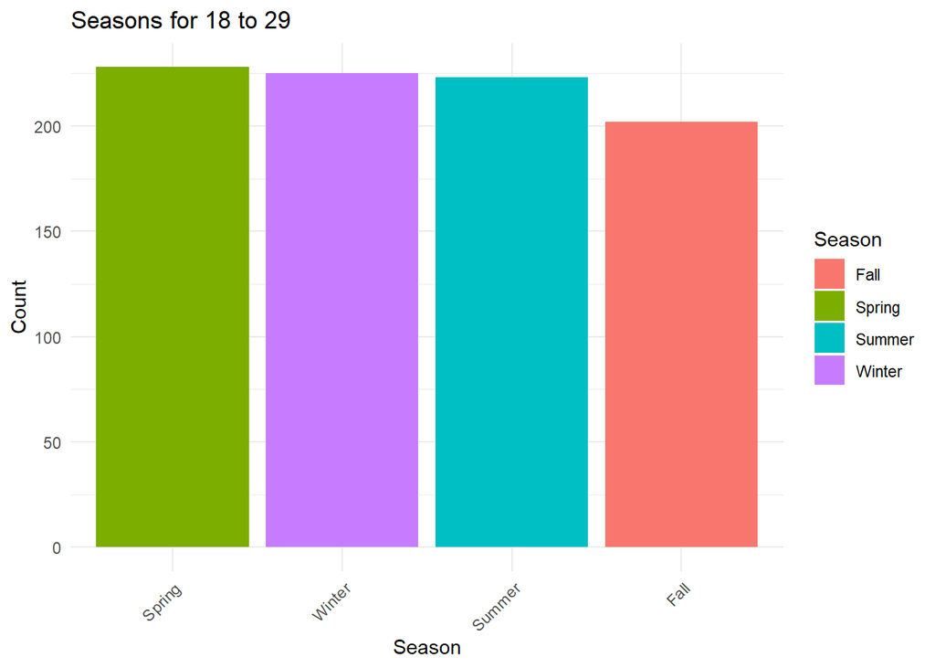

```r
seasons_18_29<-sqldf("select Season, count(Season) as count from df1  where Age between 18 and 29 group by Season order by count(Season) desc")
#View(seasons_18_29)

ggplot(seasons_18_29, aes(x = reorder(Season, -count), y = count, fill = Season)) +
  geom_bar(stat = "identity") +
  labs(title = "Seasons for 18 to 29", x = "Season", y = "Count") +
  theme_minimal() +
  theme(axis.text.x = element_text(angle = 45, hjust = 1))
```

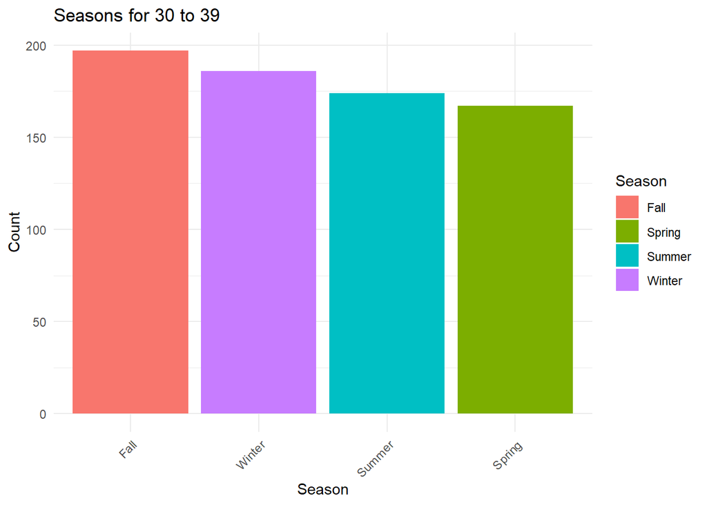

```r
seasons_30_39<-sqldf("select Season, count(Season) as count from df1  where Age between 30 and 39 group by Season order by count(Season) desc")
#View(seasons_30_39)

ggplot(seasons_30_39, aes(x = reorder(Season, -count), y = count, fill = Season)) +
  geom_bar(stat = "identity") +
  labs(title = "Seasons for 30 to 39", x = "Season", y = "Count") +
  theme_minimal() +
  theme(axis.text.x = element_text(angle = 45, hjust = 1))
```

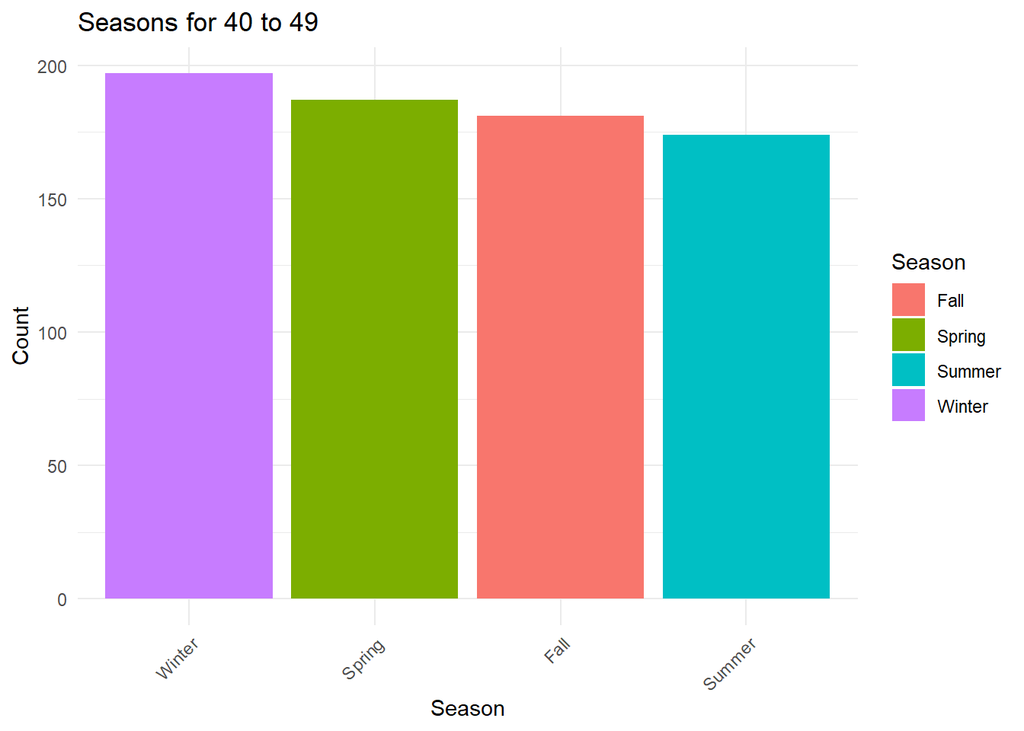

```r
seasons_40_49<-sqldf("select Season, count(Season) as count from df1  where Age between 40 and 49 group by Season order by count(Season) desc")
#View(seasons_40_49)

ggplot(seasons_40_49, aes(x = reorder(Season, -count), y = count, fill = Season)) +
  geom_bar(stat = "identity") +
  labs(title = "Seasons for 40 to 49", x = "Season", y = "Count") +
  theme_minimal() +
  theme(axis.text.x = element_text(angle = 45, hjust = 1))
```

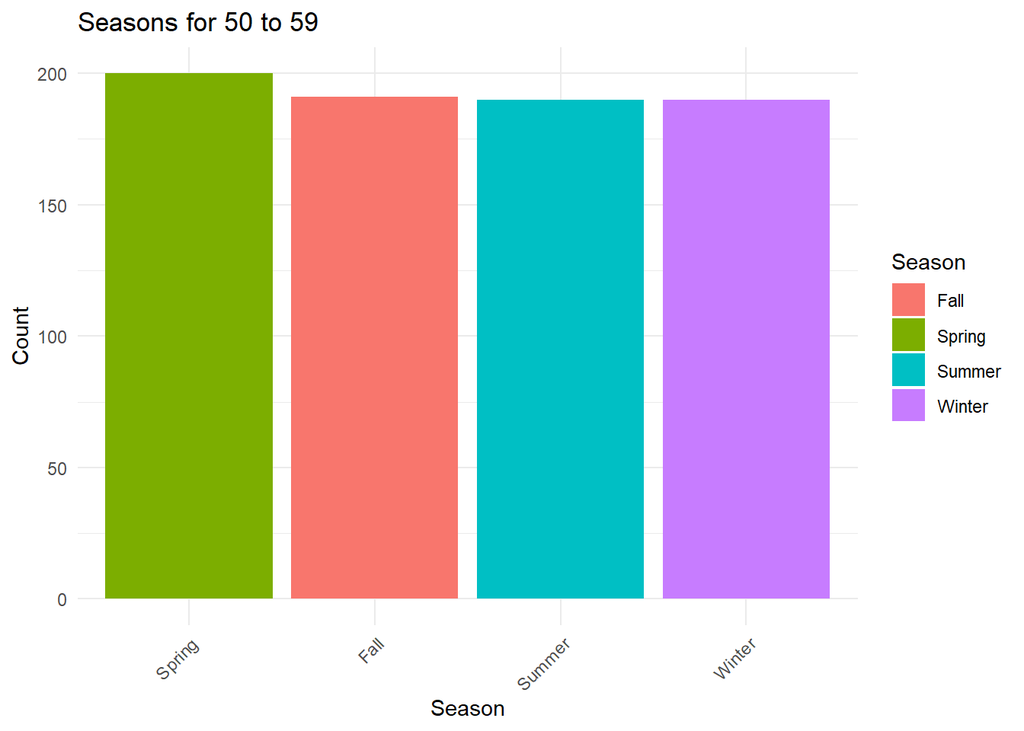

```r
seasons_50_59<-sqldf("select Season, count(Season) as count from df1  where Age between 50 and 59 group by Season order by count(Season) desc")
#View(seasons_50_59)

ggplot(seasons_50_59, aes(x = reorder(Season, -count), y = count, fill = Season)) +
  geom_bar(stat = "identity") +
  labs(title = "Seasons for 50 to 59", x = "Season", y = "Count") +
  theme_minimal() +
  theme(axis.text.x = element_text(angle = 45, hjust = 1))
```

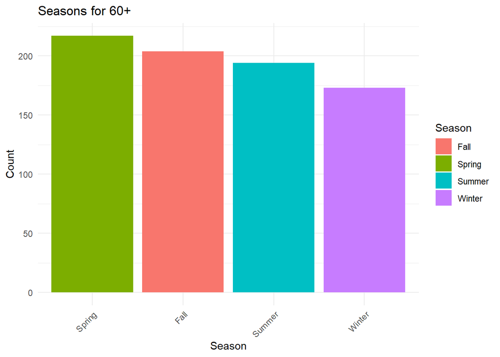

```r
seasons_60<-sqldf("select Season, count(Season) as count from df1  where Age >= 60 group by Season order by count(Season) desc")
#View(seasons_60)

ggplot(seasons_60, aes(x = reorder(Season, -count), y = count, fill = Season)) +
  geom_bar(stat = "identity") +
  labs(title = "Seasons for 60+", x = "Season", y = "Count") +
  theme_minimal() +
  theme(axis.text.x = element_text(angle = 45, hjust = 1))
```

We can see the correlation between color and season by looking at which colors are the most purchased for each season:

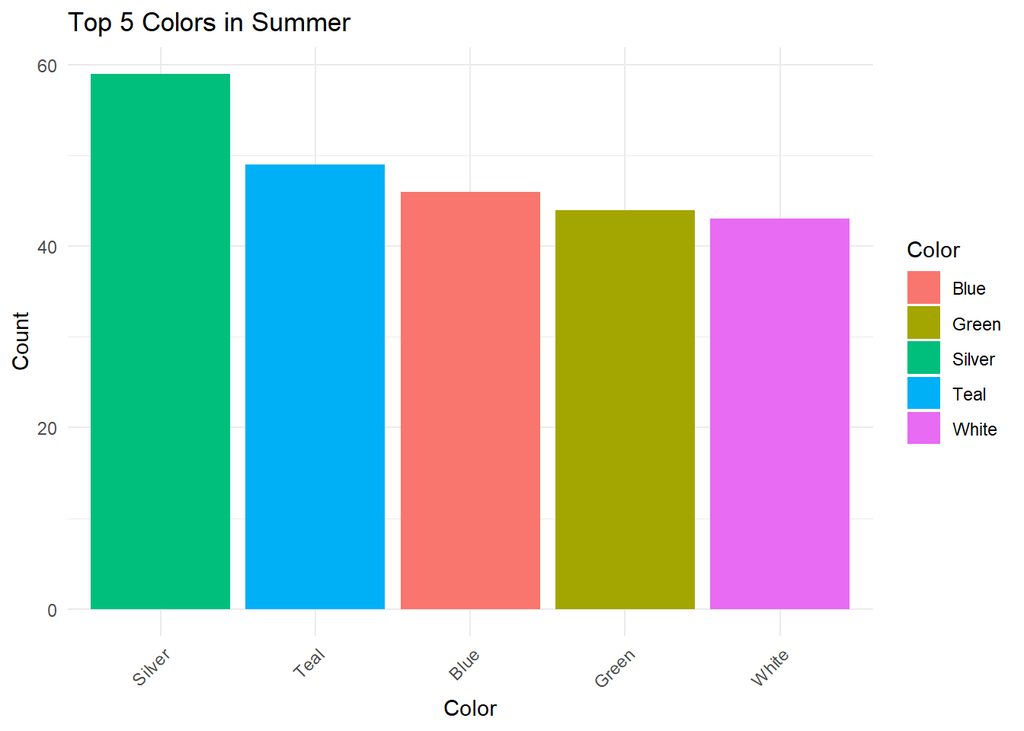

```r
top_5_color_by_season_summer<-sqldf("select Season, Color, count(Color) as count from df1 where Season == 'Summer' group by Color order by count desc limit 5")
#View(top_5_color_by_season_summer)

ggplot(top_5_color_by_season_summer, aes(x = reorder(Color, -count), y = count, fill = Color)) +
  geom_bar(stat = "identity") +
  labs(title = "Top 5 Colors in Summer", x = "Color", y = "Count") +
  theme_minimal() +
  theme(axis.text.x = element_text(angle = 45, hjust = 1))
```

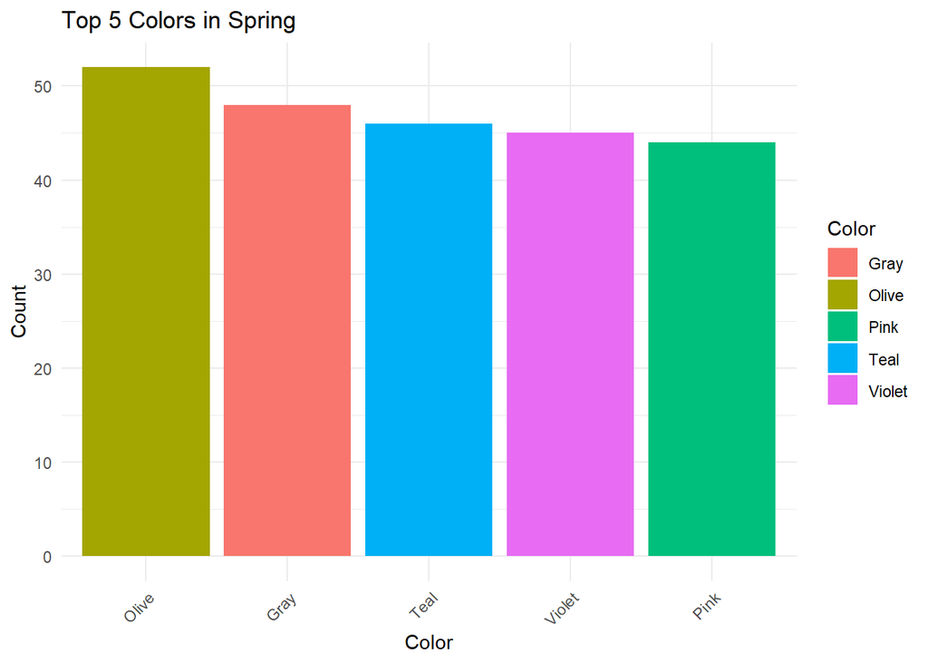

```r
top_5_color_by_season_spring<-sqldf("select Season, Color, count(Color) as count from df1 where Season == 'Spring' group by Color order by count desc limit 5")
#View(top_5_color_by_season_spring)

ggplot(top_5_color_by_season_spring, aes(x = reorder(Color, -count), y = count, fill = Color)) +
  geom_bar(stat = "identity") +
  labs(title = "Top 5 Colors in Spring", x = "Color", y = "Count") +
  theme_minimal() +
  theme(axis.text.x = element_text(angle = 45, hjust = 1))
```

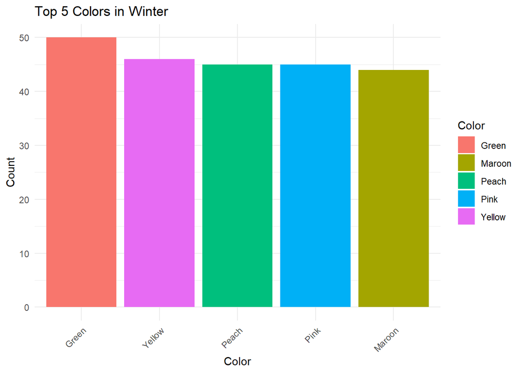

```r
top_5_color_by_season_winter<-sqldf("select Season, Color, count(Color) as count from df1 where Season == 'Winter' group by Color order by count desc limit 5")
#View(top_5_color_by_season_winter)

ggplot(top_5_color_by_season_winter, aes(x = reorder(Color, -count), y = count, fill = Color)) +
  geom_bar(stat = "identity") +
  labs(title = "Top 5 Colors in Winter", x = "Color", y = "Count") +
  theme_minimal() +
  theme(axis.text.x = element_text(angle = 45, hjust = 1))
```

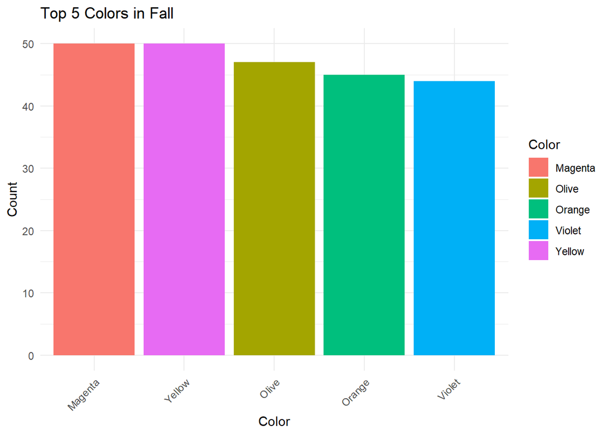

```r
top_5_color_by_season_fall<-sqldf("select Season, Color, count(Color) as count from df1 where Season == 'Fall' group by Color order by count desc limit 5")
#View(top_5_color_by_season_fall)

ggplot(top_5_color_by_season_fall, aes(x = reorder(Color, -count), y = count, fill = Color)) +
  geom_bar(stat = "identity") +
  labs(title = "Top 5 Colors in Fall", x = "Color", y = "Count") +
  theme_minimal() +
  theme(axis.text.x = element_text(angle = 45, hjust = 1))
```

We can see the variation by gender :

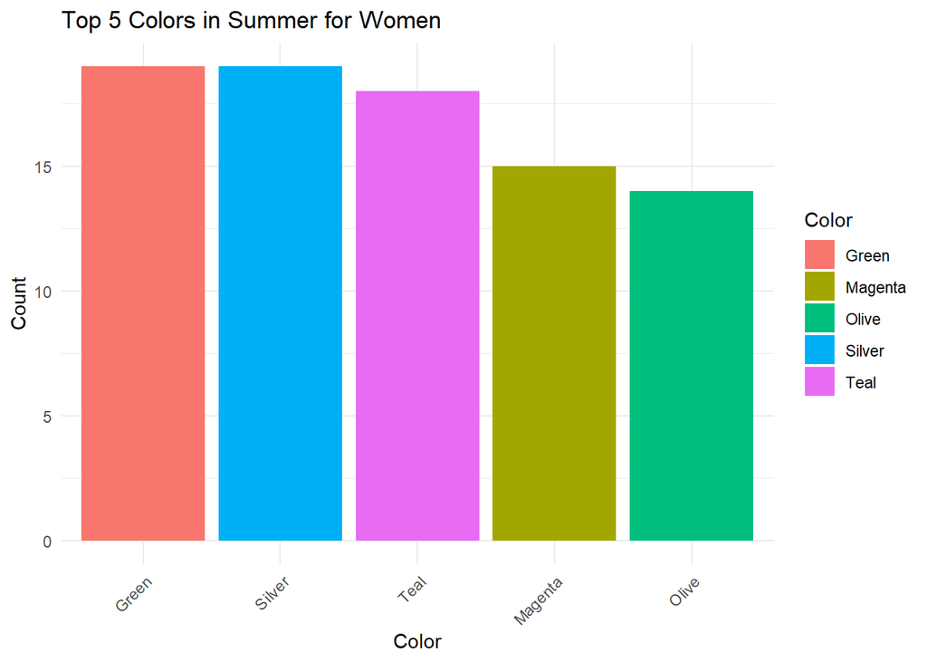

```r
top_5_color_by_season_summer_women<-sqldf("select Season, Color, count(Color) as count from df1 where Season == 'Summer'and Gender =='Female' group by Color order by count desc limit 5")
#View(top_5_color_by_season_summer_women)

ggplot(top_5_color_by_season_summer_women, aes(x = reorder(Color, -count), y = count, fill = Color)) +
  geom_bar(stat = "identity") +
  labs(title = "Top 5 Colors in Summer for Women", x = "Color", y = "Count") +
  theme_minimal() +
  theme(axis.text.x = element_text(angle = 45, hjust = 1))
```

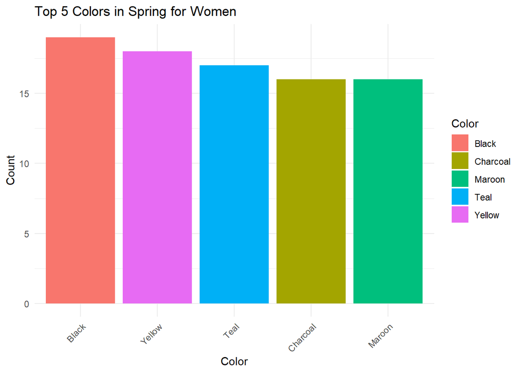

```r
top_5_color_by_season_spring_women<-sqldf("select Season, Color, count(Color) as count from df1 where Season == 'Spring' and Gender=='Female' group by Color order by count desc limit 5")
#View(top_5_color_by_season_spring_women)

ggplot(top_5_color_by_season_spring_women, aes(x = reorder(Color, -count), y = count, fill = Color)) +
  geom_bar(stat = "identity") +
  labs(title = "Top 5 Colors in Spring for Women", x = "Color", y = "Count") +
  theme_minimal() +
  theme(axis.text.x = element_text(angle = 45, hjust = 1))
```

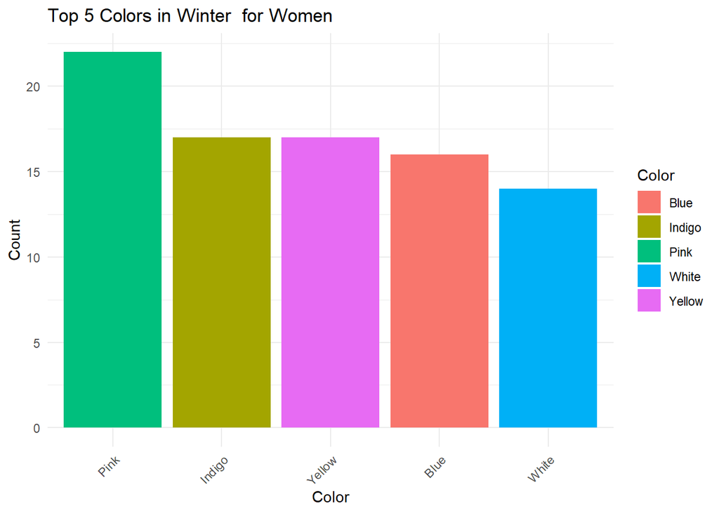

```r
top_5_color_by_season_winter_women<-sqldf("select Season, Color, count(Color) as count from df1 where Season == 'Winter' and Gender=='Female' group by Color order by count desc limit 5")
#View(top_5_color_by_season_winter_women)

ggplot(top_5_color_by_season_winter_women, aes(x = reorder(Color, -count), y = count, fill = Color)) +
  geom_bar(stat = "identity") +
  labs(title = "Top 5 Colors in Winter  for Women", x = "Color", y = "Count") +
  theme_minimal() +
  theme(axis.text.x = element_text(angle = 45, hjust = 1))
```

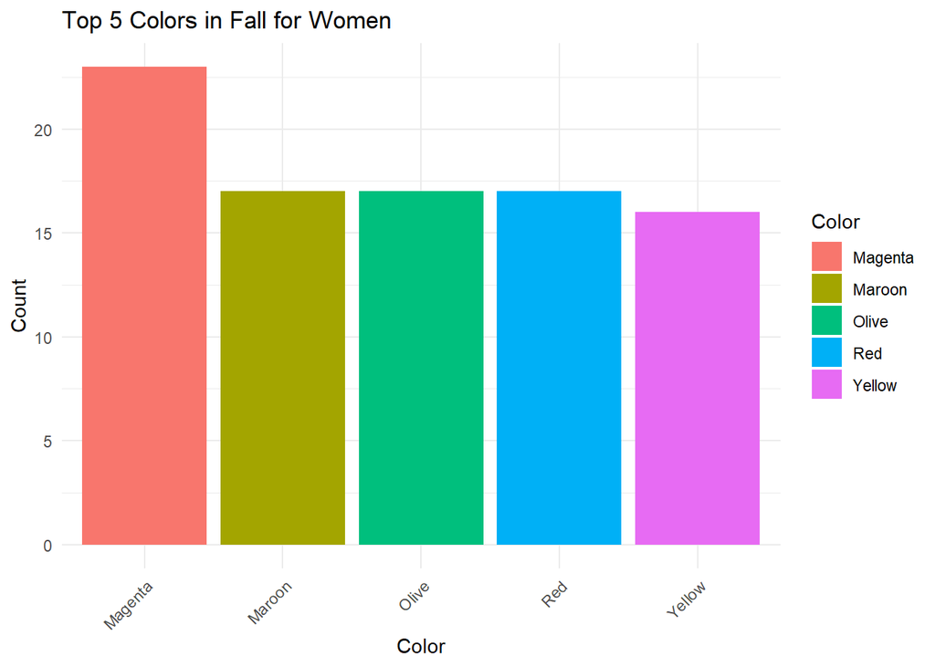

```r
top_5_color_by_season_fall_women<-sqldf("select Season, Color, count(Color) as count from df1 where Season == 'Fall' and Gender == 'Female' group by Color order by count desc limit 5")
#View(top_5_color_by_season_fall_women)

ggplot(top_5_color_by_season_fall_women, aes(x = reorder(Color, -count), y = count, fill = Color)) +
  geom_bar(stat = "identity") +
  labs(title = "Top 5 Colors in Fall for Women", x = "Color", y = "Count") +
  theme_minimal() +
  theme(axis.text.x = element_text(angle = 45, hjust = 1))
```

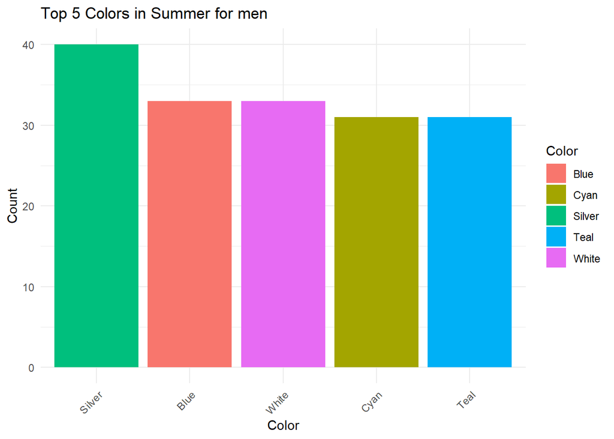

```r
top_5_color_by_season_summer_men<-sqldf("select Season, Color, count(Color) as count from df1 where Season == 'Summer'and Gender =='Male' group by Color order by count desc limit 5")
#View(top_5_color_by_season_summer_men)

ggplot(top_5_color_by_season_summer_men, aes(x = reorder(Color, -count), y = count, fill = Color)) +
  geom_bar(stat = "identity") +
  labs(title = "Top 5 Colors in Summer for men", x = "Color", y = "Count") + theme_minimal() +
  theme(axis.text.x = element_text(angle = 45, hjust = 1))
```

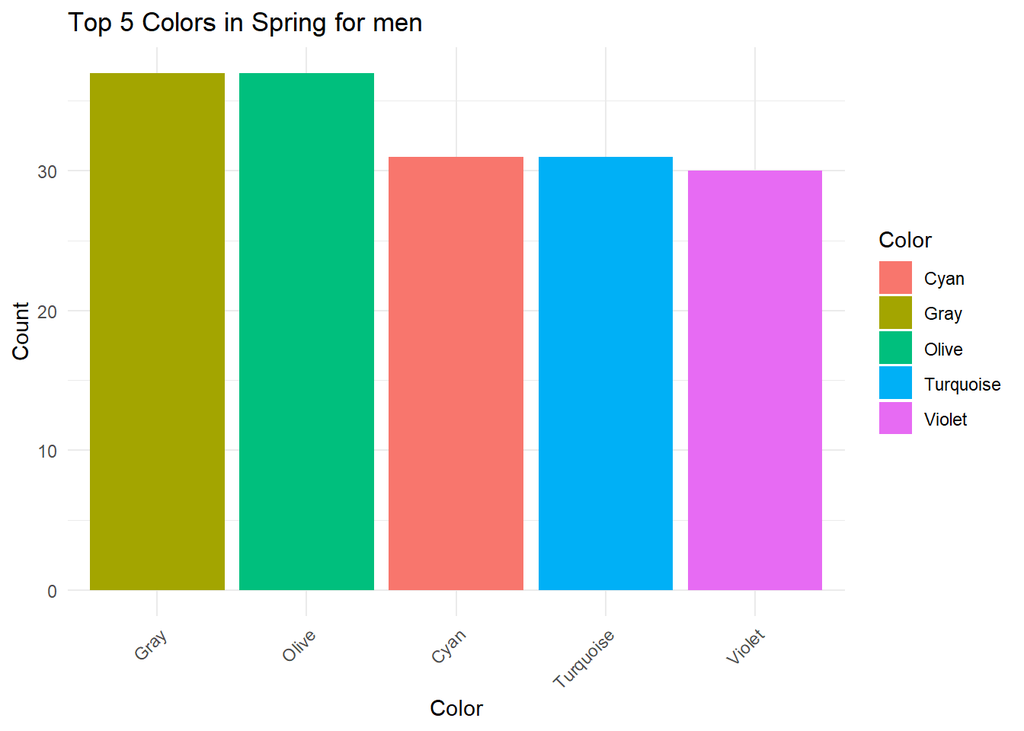

```r
top_5_color_by_season_spring_men<-sqldf("select Season, Color, count(Color) as count from df1 where Season == 'Spring' and Gender=='Male' group by Color order by count desc limit 5")
#View(top_5_color_by_season_spring_men)

ggplot(top_5_color_by_season_spring_men, aes(x = reorder(Color, -count), y = count, fill = Color)) +
  geom_bar(stat = "identity") +
  labs(title = "Top 5 Colors in Spring for men", x = "Color", y = "Count") + theme_minimal() +
  theme(axis.text.x = element_text(angle = 45, hjust = 1))
```

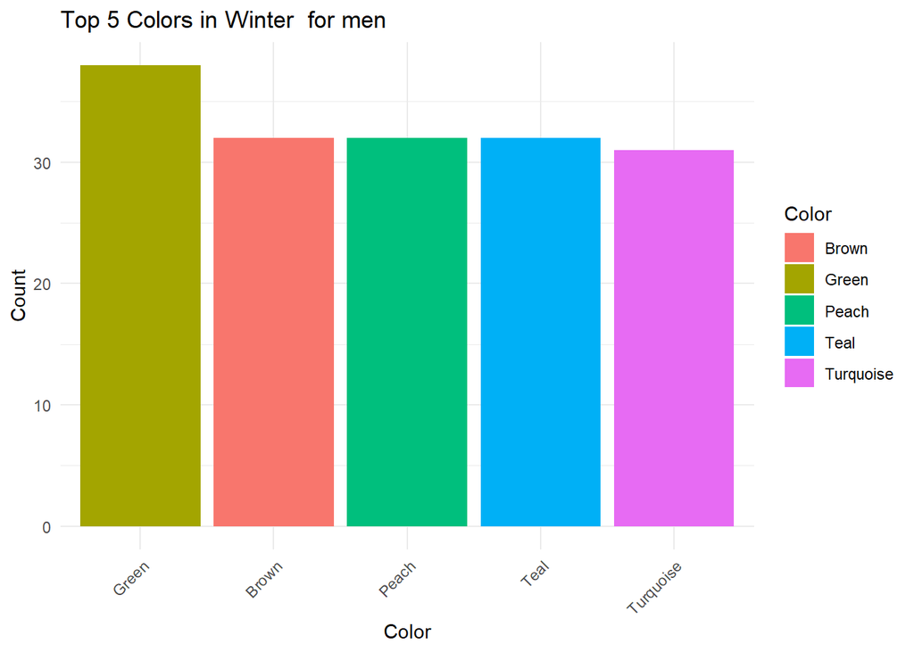

```r
top_5_color_by_season_winter_men<-sqldf("select Season, Color, count(Color) as count from df1 where Season == 'Winter' and Gender=='Male' group by Color order by count desc limit 5")
#View(top_5_color_by_season_winter_men)

ggplot(top_5_color_by_season_winter_men, aes(x = reorder(Color, -count), y = count, fill = Color)) +
  geom_bar(stat = "identity") +
  labs(title = "Top 5 Colors in Winter  for men", x = "Color", y = "Count") + theme_minimal() +
  theme(axis.text.x = element_text(angle = 45, hjust = 1))
```

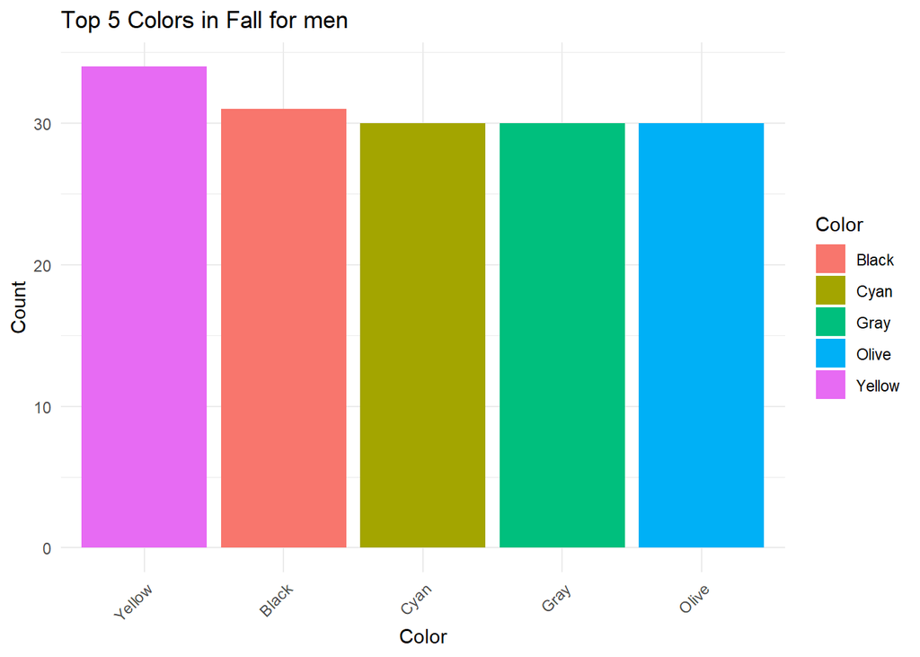

```r
top_5_color_by_season_fall_men<-sqldf("select Season, Color, count(Color) as count from df1 where Season == 'Fall' and Gender == 'Male' group by Color order by count desc limit 5")
#View(top_5_color_by_season_fall_men)

ggplot(top_5_color_by_season_fall_men, aes(x = reorder(Color, -count), y = count, fill = Color)) +
  geom_bar(stat = "identity") +
  labs(title = "Top 5 Colors in Fall for men", x = "Color", y = "Count") +
  theme_minimal() +
  theme(axis.text.x = element_text(angle = 45, hjust = 1))
```

To explore the correlation between colors and the season, we can also create a heat map:

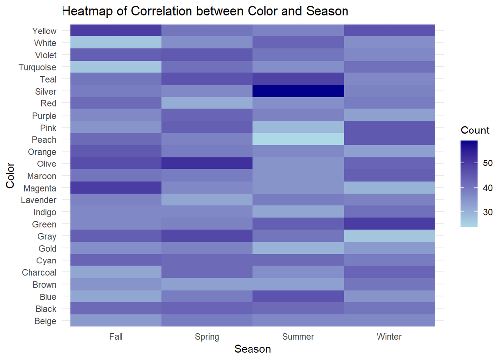

```r
color_season_heatmap <- sqldf("select Color, Season, count(*) as count from df1 group by color, season")

ggplot(color_season_heatmap, aes(x = Season, y = Color, fill = count)) +
  geom_tile() +
  labs(title = "Heatmap of Correlation between Color and Season",
       x = "Season", y = "Color", fill = "Count") +
  scale_fill_gradient(low = "lightblue", high = "darkblue") +
  theme_minimal()
```

Now we can look at the different reviews customers gave: (we group ratings from 0 to 1, 1.1 to 2 … and 4.1 to 5)

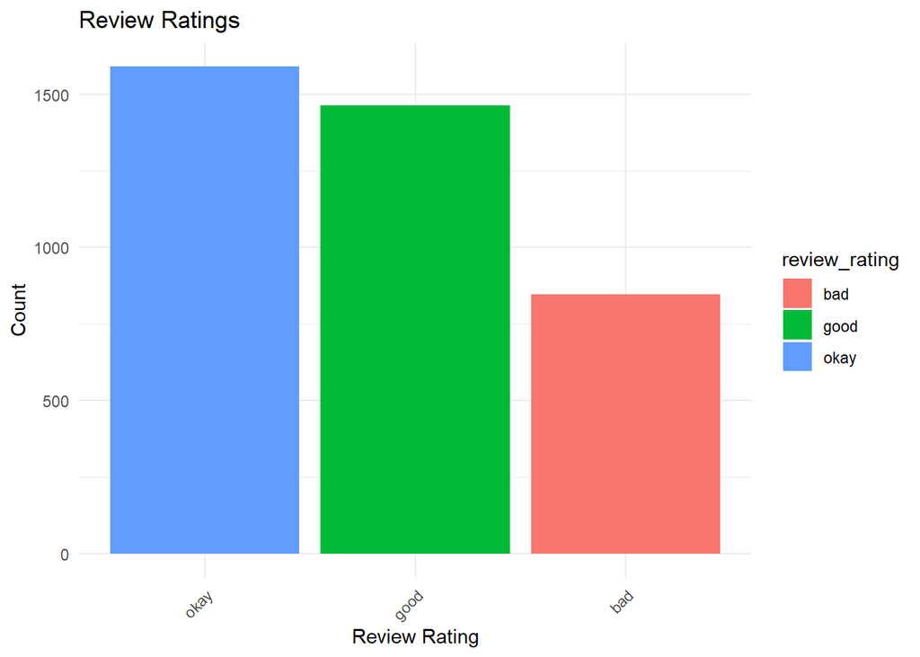

```r
reviews<-sqldf("select case when `Review.Rating` between 0 and 1 then 'terrible' when `Review.Rating` between 1.1 and 2 then 'very bad' when `Review.Rating` between 2.1 and 3 then 'bad' when `Review.Rating` between 3.1 and 4 then 'okay' else 'good' end as review_rating, count(*) as review_count from df1 group by review_rating order by review_count desc")
#View(reviews)

ggplot(reviews, aes(x = reorder(review_rating, -review_count), y = review_count, fill = review_rating)) +
  geom_bar(stat = "identity") +
  labs(title = "Review Ratings", x = "Review Rating", y = "Count") +
  theme_minimal() +
  theme(axis.text.x = element_text(angle = 45, hjust = 1))
```

Most of the reviews are either okay or good, there aren’t as many bad reviews.

We can see how this differs by gender:

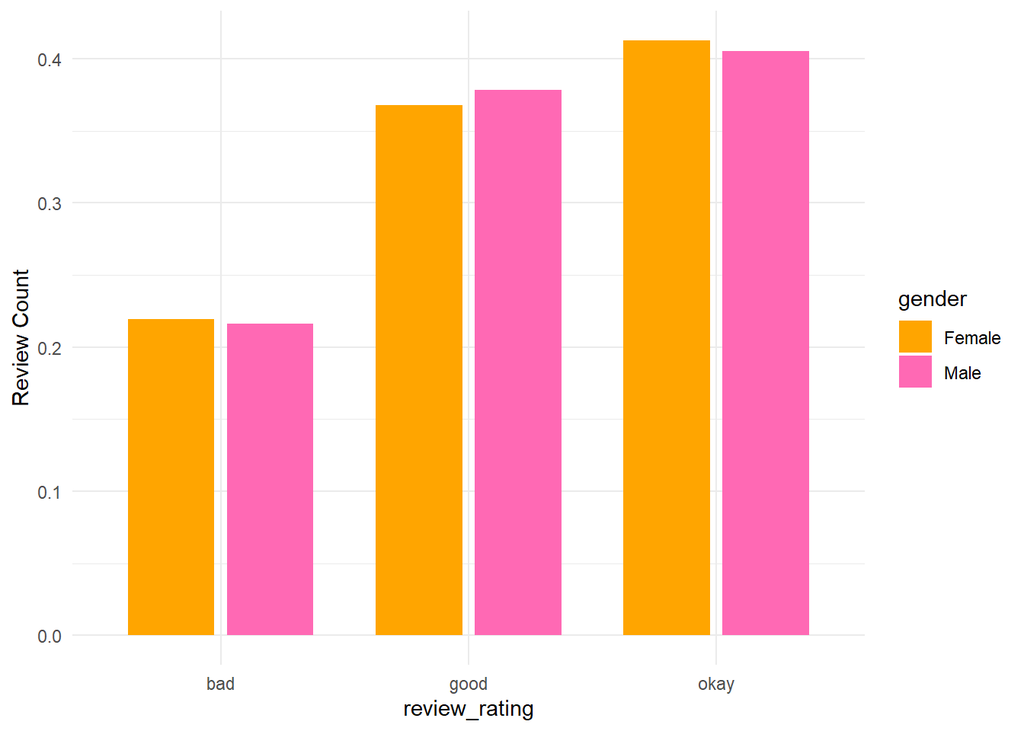

```r
# When we count the number of reviews, we need to scale those values(divide by the total number of reviews) as we want to compare by gender and in this data set there are more men.
reviews_women<-sqldf("select case when `Review.Rating` between 0 and 1 then 'terrible' when `Review.Rating` between 1.1 and 2 then 'very bad' when `Review.Rating` between 2.1 and 3 then 'bad' when `Review.Rating` between 3.1 and 4 then 'okay' else 'good' end as review_rating, count(*) / cast((select count(*) from df1 where Gender = 'Female')as float) as scaled_review_count from df1 where Gender == 'Female' group by review_rating order by scaled_review_count desc")
#View(reviews_women)

reviews_men<-sqldf("select case when `Review.Rating` between 0 and 1 then 'terrible' when `Review.Rating` between 1.1 and 2 then 'very bad' when `Review.Rating` between 2.1 and 3 then 'bad' when `Review.Rating` between 3.1 and 4 then 'okay' else 'good' end as review_rating, count(*) / cast((select count(*) from df1 where Gender = 'Male')as float) as scaled_review_count from df1 where Gender == 'Male' group by review_rating order by scaled_review_count desc")
#View(reviews_men)

#We use melt to get a bar graph with bars for each gender side by side for each type of  review
melted_reviews <- rbind(
  cbind(melt(reviews_women), gender = 'Female'),
  cbind(melt(reviews_men), gender = 'Male')
)
ggplot(melted_reviews, aes(x = review_rating, y = value, fill = gender)) +
  geom_bar(stat = "identity", position = position_dodge(width = 0.8), width = 0.7) +
  labs(y = "Review Count") +
  scale_fill_manual(values = c("Female" = "orange", "Male" = "hotpink")) +
  theme_minimal()
```

```r
reviews_by_age<-sqldf("select case when `Review.Rating` between 0 and 1 then 'terrible' when `Review.Rating` between 1.1 and 2 then 'very bad' when `Review.Rating` between 2.1 and 3 then 'bad' when `Review.Rating` between 3.1 and 4 then 'okay' else 'good' end as review_rating, case when Age between 18 and 29 then '18-29' when Age between 30 and 39 then '30-39' when Age between 40 and 49 then '40-49' when Age between 50 and 59 then '50-59' else '60+' end as Age_Group, count(*) as review_count from df1 group by Age_Group, review_rating order by Age_Group, review_count desc")
#View(reviews_by_age)
```

Now we can take a look at the frequency of purchase:

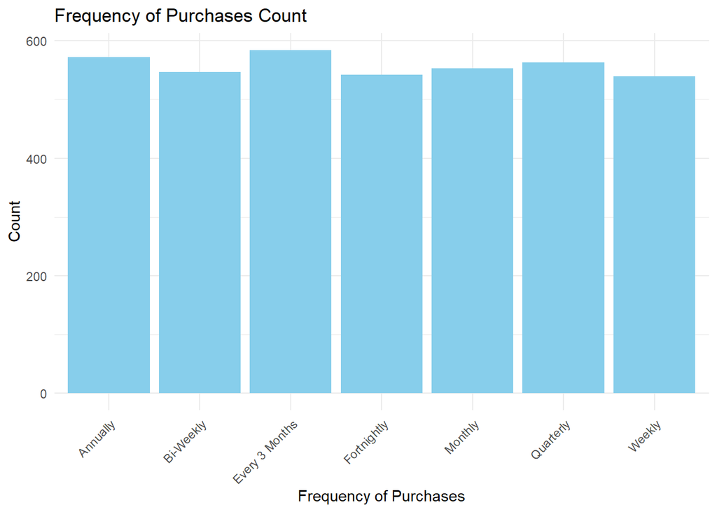

```r
#Frequency of purchase and average of previous purchases
freq_purchases_and_avg_previous_purchases<-sqldf("select `Frequency.of.Purchases`, count(`Frequency.of.Purchases`) as count_freq_purchase, avg(`Previous.Purchases`) as avg_prev_purchase from df1 group by `Frequency.of.Purchases` order by count_freq_purchase desc")
#View(freq_purchases_and_avg_previous_purchases)

ggplot(freq_purchases_and_avg_previous_purchases, aes(x = `Frequency.of.Purchases`)) +
  geom_bar(aes(y = count_freq_purchase), stat = "identity", fill = "skyblue") +
  labs(title = "Frequency of Purchases Count",
       x = "Frequency of Purchases",
       y = "Count") +
  theme_minimal() + theme(axis.text.x = element_text(angle = 45, hjust = 1))
```

We can see that there aren’t any frequency that particularly stand out or where more people purchase items.  
We can see if there is a difference according to gender:

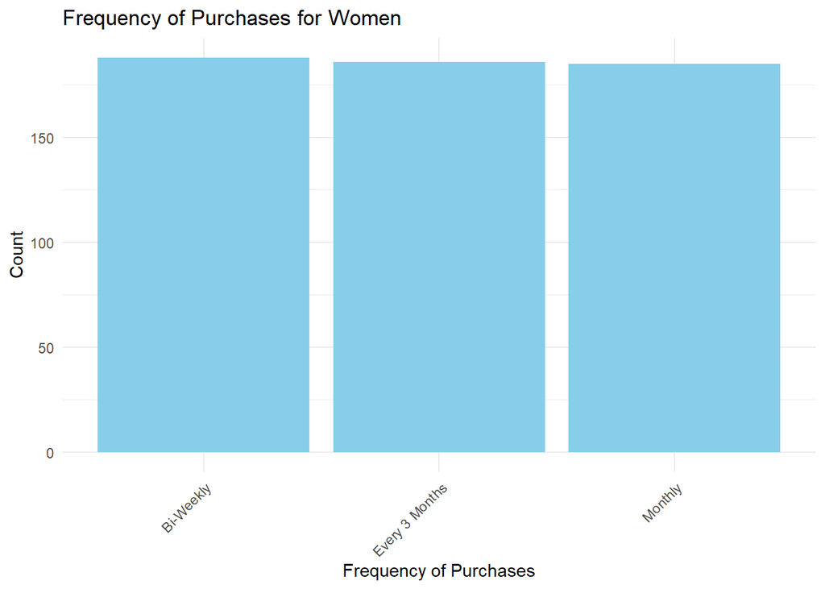

```r
freq_purchases_women<-sqldf("select `Frequency.of.Purchases`, count(`Frequency.of.Purchases`) as count_freq_purchase from df1 where Gender == 'Female' group by `Frequency.of.Purchases` order by count_freq_purchase desc limit 3")
#View(freq_purchases_women)

ggplot(freq_purchases_women, aes(x = `Frequency.of.Purchases`)) +
  geom_bar(aes(y = count_freq_purchase), stat = "identity", fill = "skyblue") +
  labs(title = "Frequency of Purchases for Women",
       x = "Frequency of Purchases",
       y = "Count") +
  theme_minimal() + theme(axis.text.x = element_text(angle = 45, hjust = 1))
```

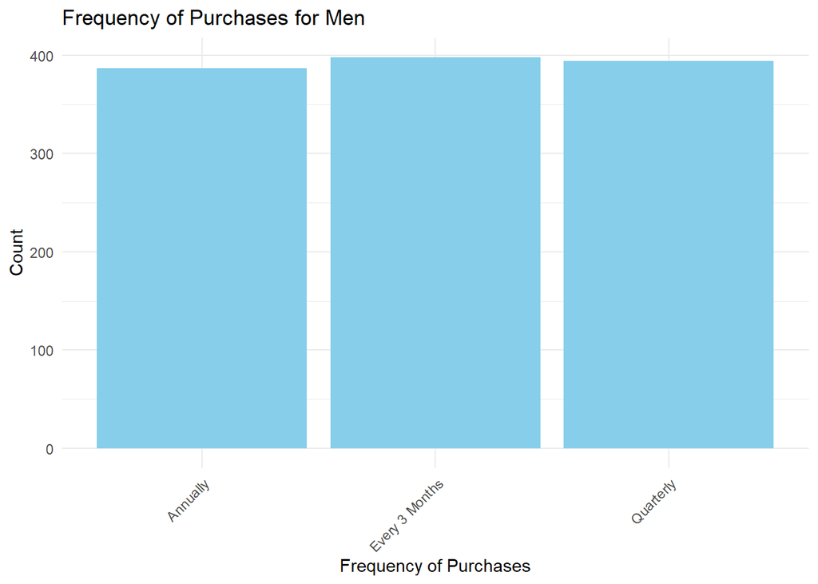

```r
freq_purchases_men<-sqldf("select `Frequency.of.Purchases`, count(`Frequency.of.Purchases`) as count_freq_purchase from df1 where Gender == 'Male' group by `Frequency.of.Purchases` order by count_freq_purchase desc limit 3")
#View(freq_purchases_men)

ggplot(freq_purchases_men, aes(x = `Frequency.of.Purchases`)) +
  geom_bar(aes(y = count_freq_purchase), stat = "identity", fill = "skyblue") +
  labs(title = "Frequency of Purchases for Men",
       x = "Frequency of Purchases",
       y = "Count") +
  theme_minimal() + theme(axis.text.x = element_text(angle = 45, hjust = 1))
```

We can notice that women tend to make online clothing purchases more frequently than men do.  
We can see if their is variation among different age groups:

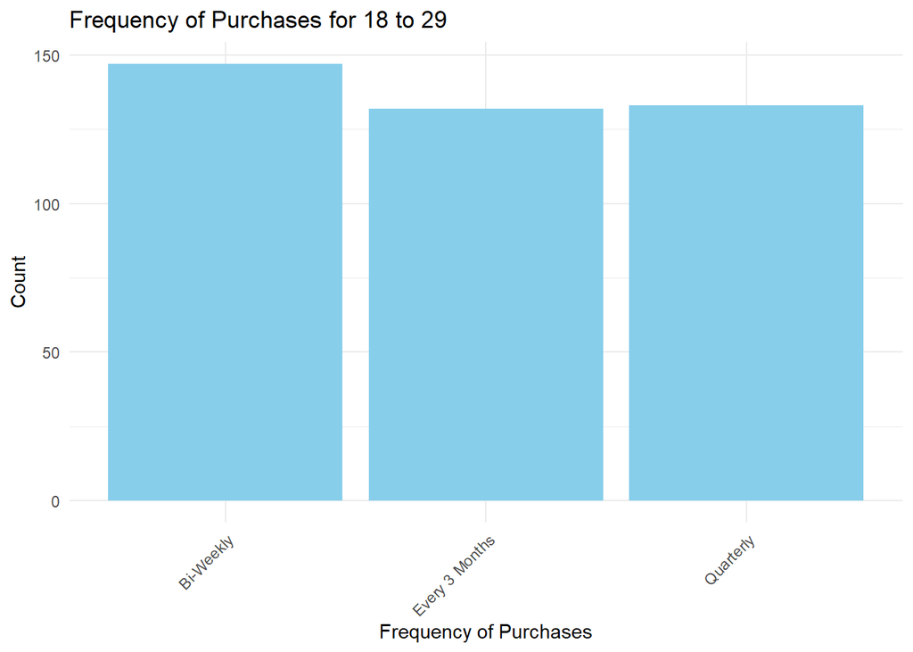

```r
freq_purchases_18_29<-sqldf("select `Frequency.of.Purchases`, count(`Frequency.of.Purchases`) as count_freq_purchase from df1 where Age between 18 and 29 group by `Frequency.of.Purchases` order by count_freq_purchase desc limit 3")
#View(freq_purchases_18_29)

ggplot(freq_purchases_18_29, aes(x = `Frequency.of.Purchases`)) +
  geom_bar(aes(y = count_freq_purchase), stat = "identity", fill = "skyblue") +
  labs(title = "Frequency of Purchases for 18 to 29",
       x = "Frequency of Purchases",
       y = "Count") +
  theme_minimal() + theme(axis.text.x = element_text(angle = 45, hjust = 1))
```

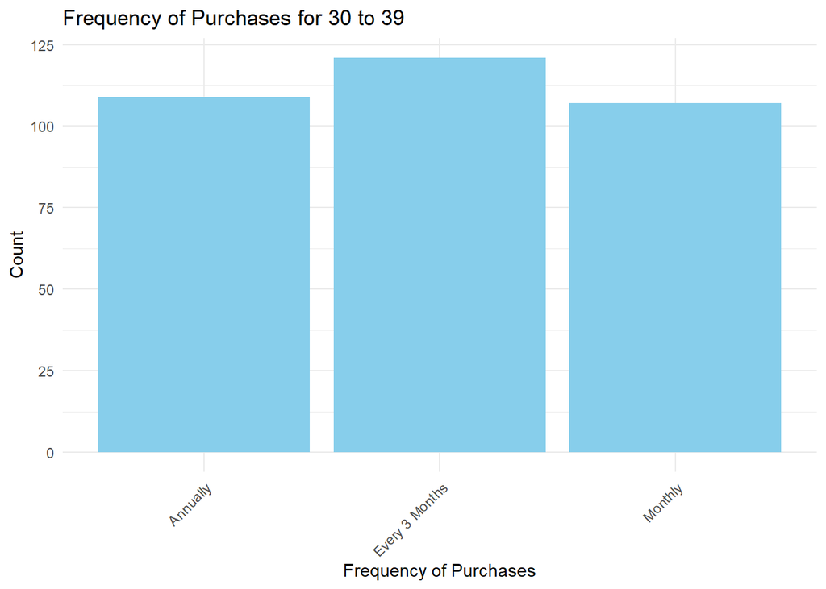

```r
freq_purchases_30_39<-sqldf("select `Frequency.of.Purchases`, count(`Frequency.of.Purchases`) as count_freq_purchase from df1 where Age between 30 and 39 group by `Frequency.of.Purchases` order by count_freq_purchase desc limit 3")
#View(freq_purchases_30_39)

ggplot(freq_purchases_30_39, aes(x = `Frequency.of.Purchases`)) +
  geom_bar(aes(y = count_freq_purchase), stat = "identity", fill = "skyblue") +
  labs(title = "Frequency of Purchases for 30 to 39",
       x = "Frequency of Purchases",
       y = "Count") +
  theme_minimal() + theme(axis.text.x = element_text(angle = 45, hjust = 1))
```

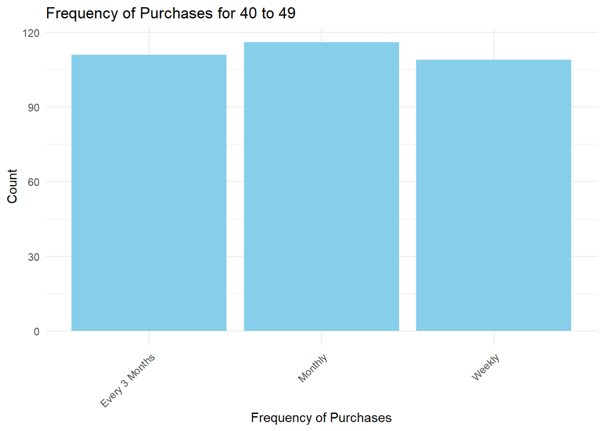

```r
freq_purchases_40_49<-sqldf("select `Frequency.of.Purchases`, count(`Frequency.of.Purchases`) as count_freq_purchase from df1 where Age between 40 and 49 group by `Frequency.of.Purchases` order by count_freq_purchase desc limit 3")
#View(freq_purchases_40_49)

ggplot(freq_purchases_40_49, aes(x = `Frequency.of.Purchases`)) +
  geom_bar(aes(y = count_freq_purchase), stat = "identity", fill = "skyblue") +
  labs(title = "Frequency of Purchases for 40 to 49",
       x = "Frequency of Purchases",
       y = "Count") +
  theme_minimal() + theme(axis.text.x = element_text(angle = 45, hjust = 1))
```

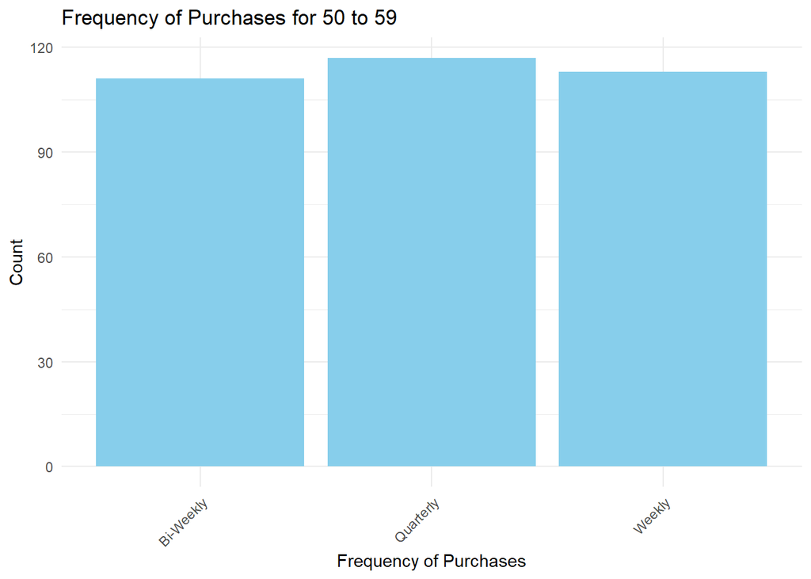

```r
freq_purchases_50_59<-sqldf("select `Frequency.of.Purchases`, count(`Frequency.of.Purchases`) as count_freq_purchase from df1 where Age between 50 and 59 group by `Frequency.of.Purchases` order by count_freq_purchase desc limit 3")
#View(freq_purchases_50_59)

ggplot(freq_purchases_50_59, aes(x = `Frequency.of.Purchases`)) +
  geom_bar(aes(y = count_freq_purchase), stat = "identity", fill = "skyblue") +
  labs(title = "Frequency of Purchases for 50 to 59",
       x = "Frequency of Purchases",
       y = "Count") +
  theme_minimal() + theme(axis.text.x = element_text(angle = 45, hjust = 1))
```

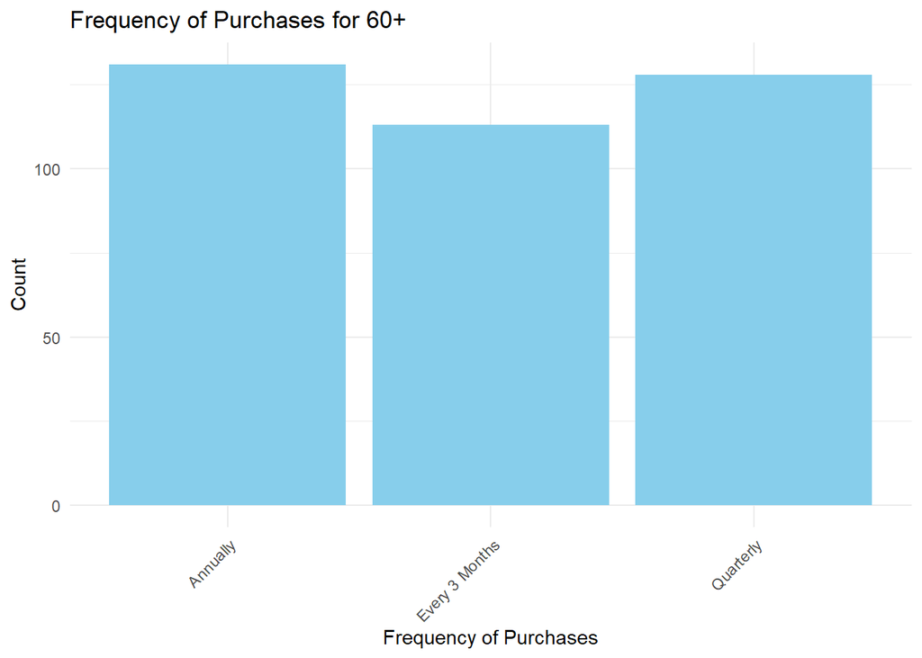

```r
freq_purchases_60<-sqldf("select `Frequency.of.Purchases`, count(`Frequency.of.Purchases`) as count_freq_purchase from df1 where Age >= 60 group by `Frequency.of.Purchases` order by count_freq_purchase desc limit 3")
#View(freq_purchases_60)

ggplot(freq_purchases_60, aes(x = `Frequency.of.Purchases`)) +
  geom_bar(aes(y = count_freq_purchase), stat = "identity", fill = "skyblue") +
  labs(title = "Frequency of Purchases for 60+",
       x = "Frequency of Purchases",
       y = "Count") +
  theme_minimal() + theme(axis.text.x = element_text(angle = 45, hjust = 1))
```

We can notice that there is variation for each age group,with older people buying less frequently than younger people.  
We can also look at where each of the customers are from:

```r
location <-sqldf("select lower(Location) as Location, count(Location) as count from df1 group by Location order by count desc")
#View(location)
```

We will use this query to plot a more complex visual (using the maps package) for one of our 3 visualizations.

Now we can move on to queries using df2:  
We can look at the gender split in this data set:

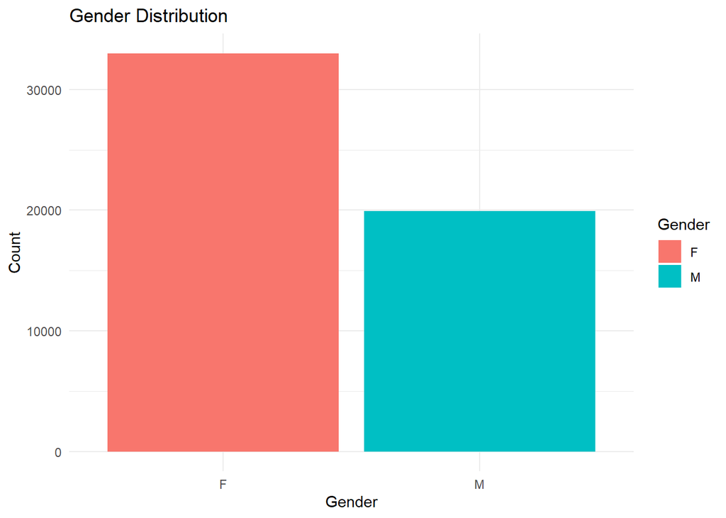

```r
gender2 <-sqldf("select Gender, count(Gender) as count from df2 group by Gender")
#View(gender2)

ggplot(gender2, aes(x = Gender, y = count, fill = Gender)) +
  geom_bar(stat = "identity") +
  labs(title = "Gender Distribution", x = "Gender", y = "Count") +
  theme_minimal()
```

This data set is also imbalanced, having more female customers.

We can which location customers are from:

```r
location2 <-sqldf("select Location, count(Location) as count from df2 group by Location order by count desc")
#View(location2)
```

This data set only has customers living in 5 possible locations.  
Now that we are have completed the exploratory analysis, we can move on to the visualizations:

Visual 1: Top 10 most purchased items

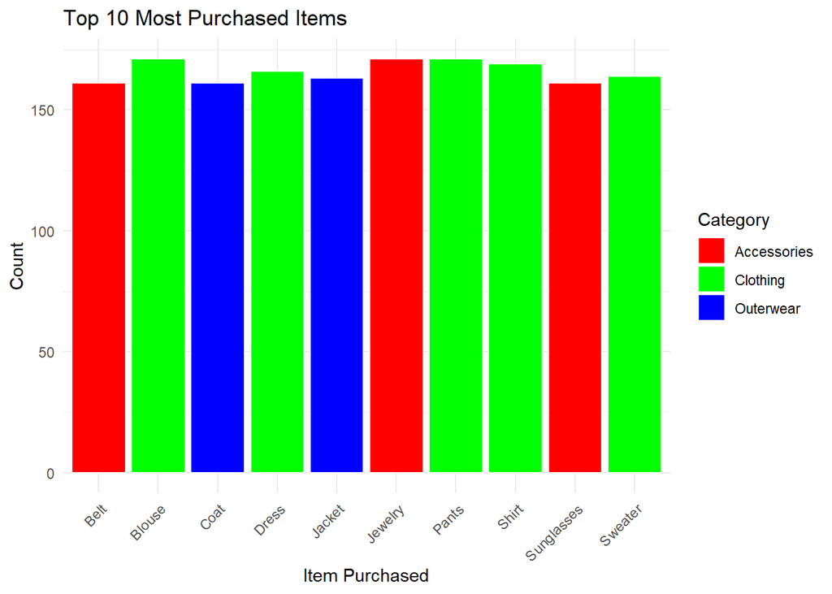

```r
#We get the top 10 most purhased items
top_10_purchases<-sqldf("select Category, `Item.Purchased`, count(`Item.Purchased`) as count,  avg(`Purchase.Amount..USD.`) as avg_price from df1 group by `Item.Purchased` order by count desc limit 10")
#View(top_10_purchases)

#we plot the top 10 items in a bar chart, coloring by category
ggplot(top_10_purchases, aes(x = `Item.Purchased`, y = count, fill = Category)) + geom_bar(stat = "identity", color = "white") +
labs(title = "Top 10 Most Purchased Items", x = "Item Purchased", y = "Count") + scale_fill_manual(values= rainbow(length(unique(top_10_purchases$Category)))) + theme_minimal() +
theme(axis.text.x = element_text(angle = 45, hjust = 1))
```

We can improve the visual by reordering the items in descending order and changing the colors:

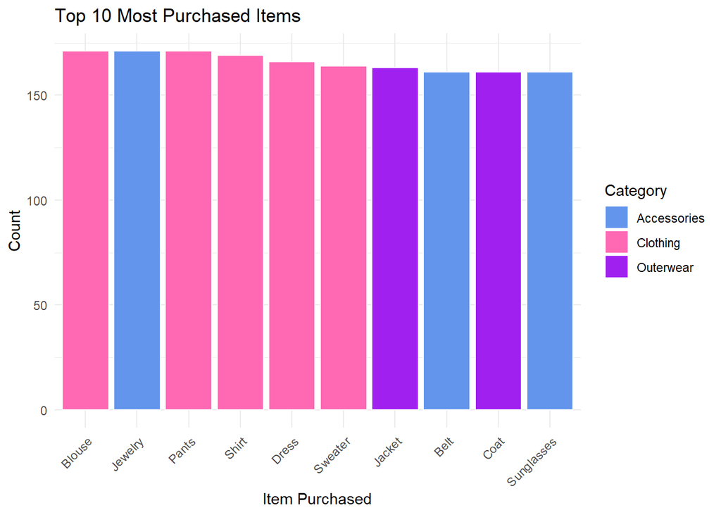

```r
#we reorder the items
top_10_purchases <- top_10_purchases[order(-top_10_purchases$count),]

ggplot(top_10_purchases, aes(x = reorder(`Item.Purchased`, -count), y = count, fill = Category)) + geom_bar(stat = "identity", color = "white") +
labs(title = "Top 10 Most Purchased Items", x = "Item Purchased", y = "Count") + scale_fill_manual(values = c("Clothing" = "hotpink", "Accessories" = "cornflowerblue", "Outerwear" = "purple", "Footwear" = "orange")) + theme_minimal() + theme(axis.text.x = element_text(angle = 45, hjust = 1))
```

We can further improve the graph by adding a more visible border to each bar and adding text showing the count of each item:

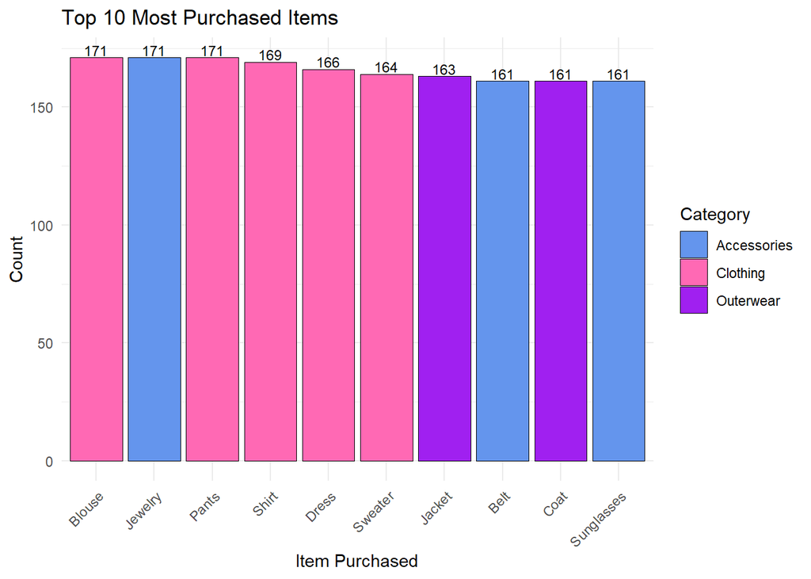

```r
plot <- ggplot(top_10_purchases, aes(x = reorder(`Item.Purchased`, -count), y = count, fill = Category)) + geom_bar(stat = "identity", color = "black", size = 0.2) + labs(title = "Top 10 Most Purchased Items", x = "Item Purchased", y = "Count") + scale_fill_manual(values = c("Clothing" = "hotpink", "Accessories" = "cornflowerblue", "Outerwear" = "purple", "Footwear" = "orange")) + theme_minimal() + theme(axis.text.x = element_text(angle = 45, hjust = 1))
#we add the count on top of each bar
plot + geom_text(aes(label = count), vjust = -0.2, color = "black", size = 3)
```

Visual 2: Location of the customers

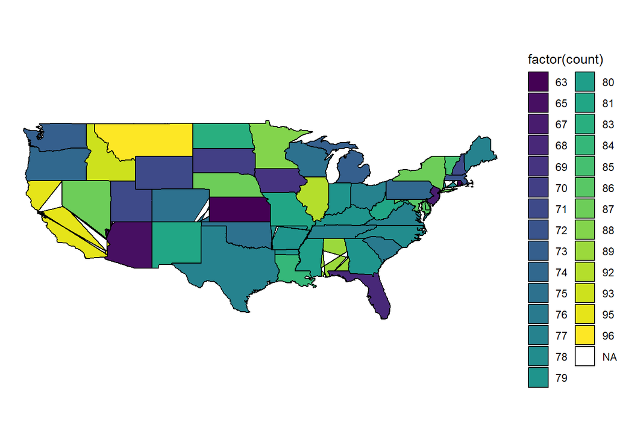

```r
#We want to know where the customers are from
location <-sqldf("select lower(Location) as Location, count(Location) as count from df1 group by Location order by count desc")
#View(location)

#we use the map of the USA from the maps library
us_states <- map_data("state")

#We add our count column to us_states data frame that contains the latitude and longitude of each state
merged_data <- merge(us_states, location, by.x = "region", by.y = "Location", all.x = TRUE)
#View(merged_data)

#We plot a heat map onto the map of  the USA, coloring by customer count
ggplot() + geom_map(data = merged_data, map = merged_data, aes(x = long, y = lat, map_id = region), fill = "white", color = "black", size = 0.25) + geom_map(data = merged_data, map = merged_data, aes(fill = factor(count), map_id = region), color = "black", size = 0.5) +
scale_fill_viridis_d() + theme_void() + coord_fixed()
```

We can adjust the legend to be on a continuous scale (to remove the unnecessary labels):

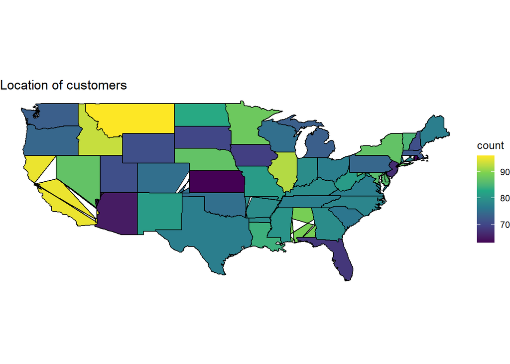

```r
ggplot() + geom_map(data = merged_data, map = merged_data, aes(x = long, y = lat, map_id = region), fill = "white", color = "black", size = 0.25) + geom_map(data = merged_data, map = merged_data, aes(fill = count, map_id = region), color = "black", size = 0.5) + labs(title = "Location of customers") + scale_fill_viridis_c() +
theme_void() + coord_fixed()
```

I also tried to make the map interactive using the plotly and overlay bubbles for the highest count states, but the graph was not working properly. The bubbles were appearing on the state borders (maybe because of the longitude and latitude in the merged data data frame) instead of in the area of the state and I couldn’t get it to work.

Visual 3: Repeat Rate and Customer Traffic

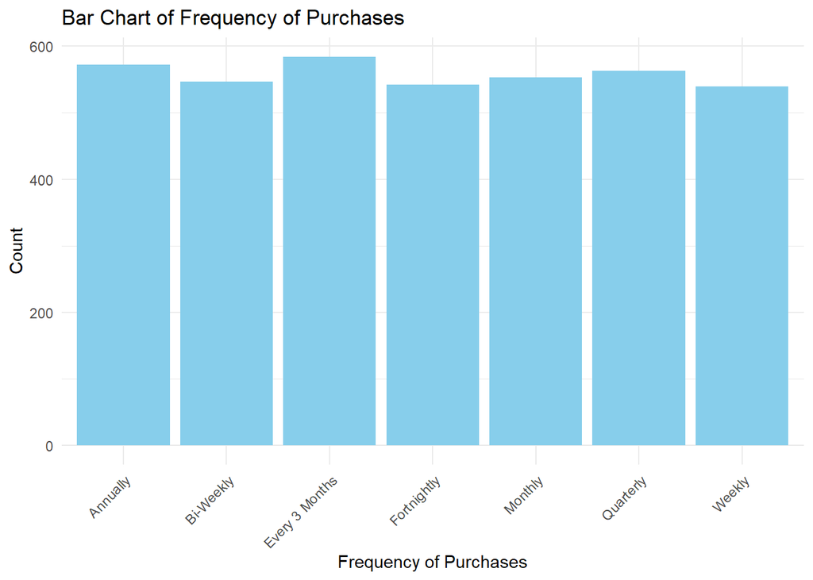

```r
#We have the frequency of purchase
freq_purchases<-sqldf("select `Frequency.of.Purchases`, count(`Frequency.of.Purchases`) as count_freq_purchase from df1 group by `Frequency.of.Purchases` order by count_freq_purchase desc")
#View(freq_purchases)

ggplot(freq_purchases, aes(x = `Frequency.of.Purchases`)) +
  geom_bar(aes(y = count_freq_purchase), stat = "identity", fill = "skyblue") + labs(title = "Bar Chart of Frequency of Purchases", x = "Frequency of Purchases", y = "Count") + theme_minimal() + theme(axis.text.x = element_text(angle = 45, hjust = 1))
```

We can change the color used to represent each category:

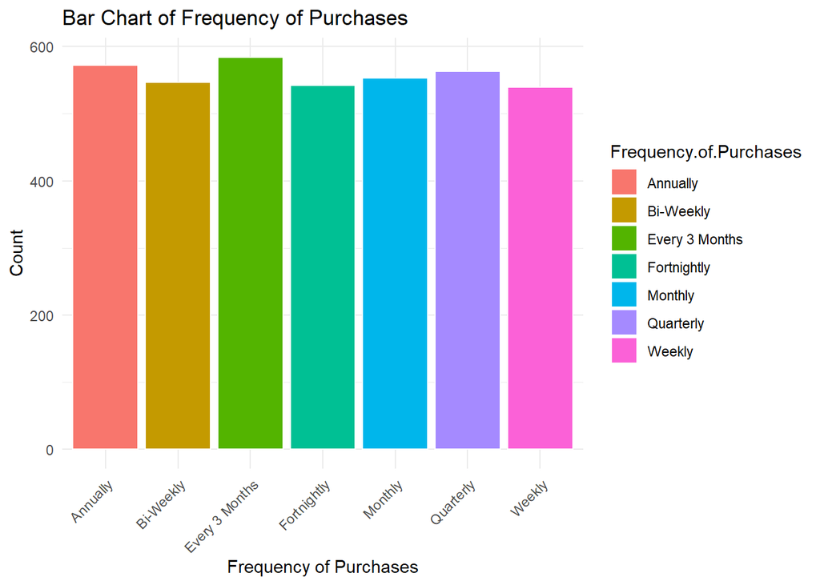

```r
ggplot(freq_purchases, aes(x = `Frequency.of.Purchases`, y = count_freq_purchase, fill = `Frequency.of.Purchases`)) +
geom_bar(stat = "identity", position = "dodge", color = "white") +
labs(title = "Bar Chart of Frequency of Purchases", x = "Frequency of Purchases", y = "Count") +
theme_minimal() +theme(axis.text.x = element_text(angle = 45, hjust = 1))
```

We can try to use an area chart instead and stack the bars horizontally:

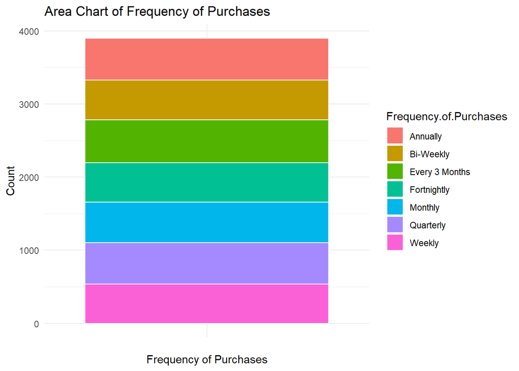

```r
ggplot(freq_purchases, aes(x = "", y = count_freq_purchase, fill = `Frequency.of.Purchases`)) + geom_bar(stat = "identity", position = "stack", color = "white") + labs(title = "Area Chart of Frequency of Purchases", x = "Frequency of Purchases", y = "Count") + theme_minimal()
```

Because the count for each categories are very close in value, the variations aren’t visible enough. We can try using a line chart instead:

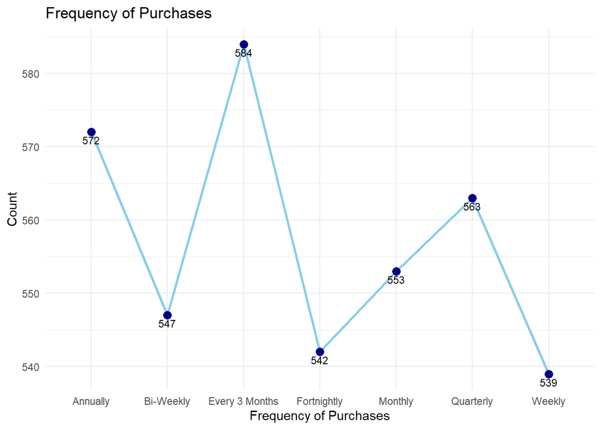

```r
plot <- ggplot(freq_purchases, aes(x = `Frequency.of.Purchases`, y = count_freq_purchase, group = 1)) + geom_line(color = "skyblue", size = 1) + geom_point(color = "darkblue", size = 3) + labs(title = "Frequency of Purchases", x = "Frequency of Purchases", y = "Count") + theme_minimal()

plot + geom_text(aes(label = count_freq_purchase), vjust = 1.5, color = "black", size = 3)
```